# ECON 475 Final Project

# Question 3. Use the dataset disney_stock_price.csv that is available on Canvas. The variable dis- ney_stock is the closing price of Disney stock in the day. The sample is at daily frequency and covers the period from January 3, 2007 to November 13, 2024. Define the training sample as all information available up to September 2024.

## (a) Let Pt denote the close price of the Disney stock. Plot the log of Pt over time, together with the correlogram of the data. Is there any evidence that the data is non-stationary? Explain your answer.

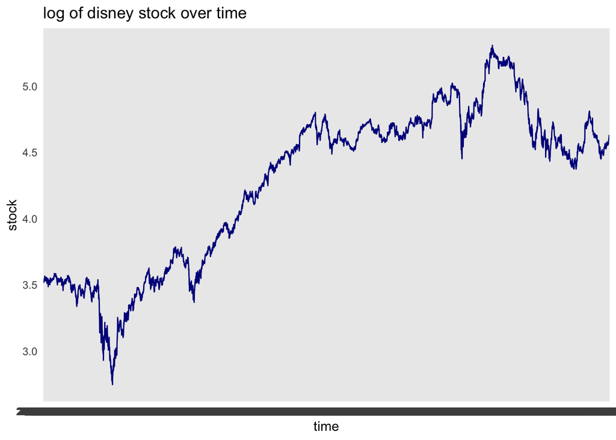

```r
library(dplyr)
disney <- read.csv("disney_stock_price.csv")
disney$X <- NULL

ggplot(disney, aes(x = date, y = log(disney_stock))) +
  geom_line(color = "darkblue", group = 1) +
  labs(title = "log of disney stock over time", x = "time",
       y = "stock") +
  theme_minimal()
```

```r
disney$rt <- c(NA, diff(log(disney$disney_stock)))
length(disney$disney_stock)
```

```
## [1] 4498
```

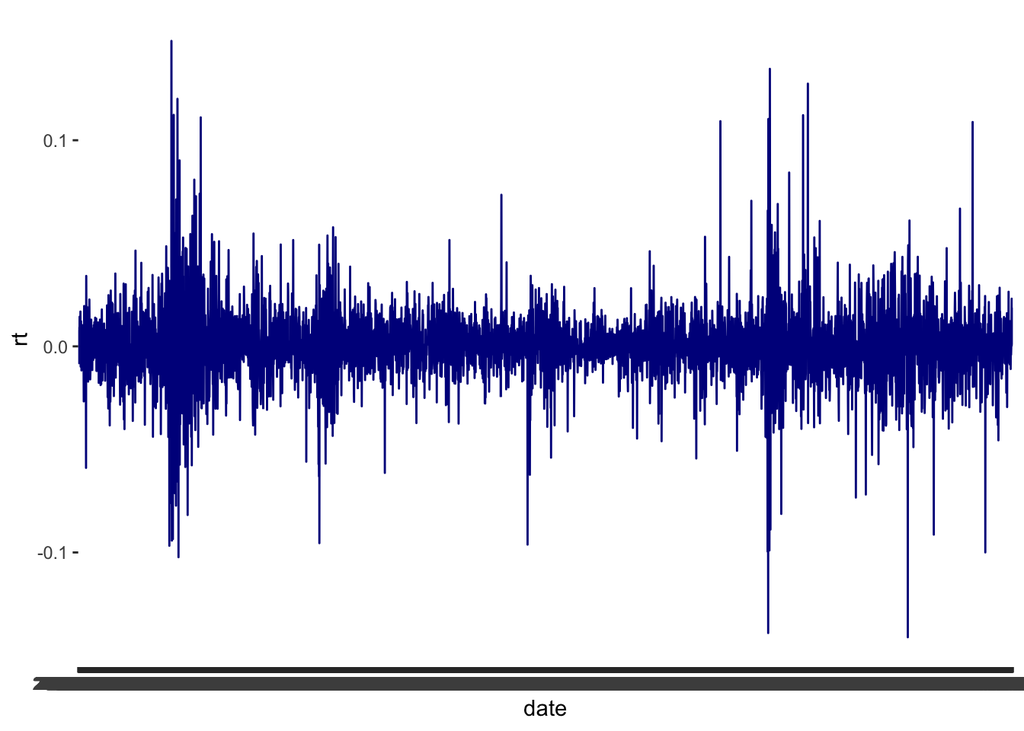

```r
ggplot(disney, aes(x = date, y = rt)) +
  geom_line(color = "darkblue", group = 1)
```

there is definitely some volatility clustering

## (c) Plot the histogram and compute the descriptive statistics of rt (mean, median, standard deviation, skewness and kurtosis). Is there any evidence that the data is leptokurtic?

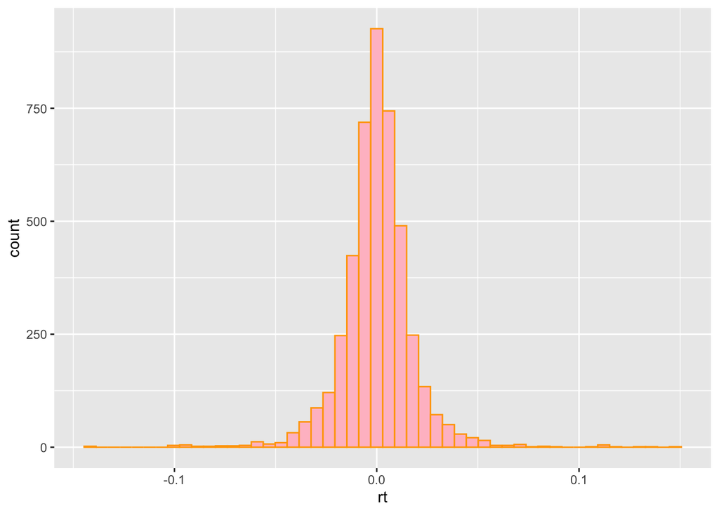

```r
library(moments)
ggplot(disney, aes(x = rt)) +
  geom_histogram(bins = 50, fill = "pink", color = "orange")
```

```r
skewness(disney$rt, na.rm = TRUE)
```

```
## [1] 0.09202811
```

```r
kurtosis(disney$rt, na.rm = TRUE)
```

```
## [1] 12.37177
```

```r
summary(disney$rt)
```

```
##       Min.    1st Qu.     Median       Mean    3rd Qu.       Max.       NA's
## -0.1411393 -0.0076871  0.0003780  0.0002476  0.0084710  0.1481804          1
```

lets be honest, a fourth central moment around the mean of 12 is WILDLY leptokurtic

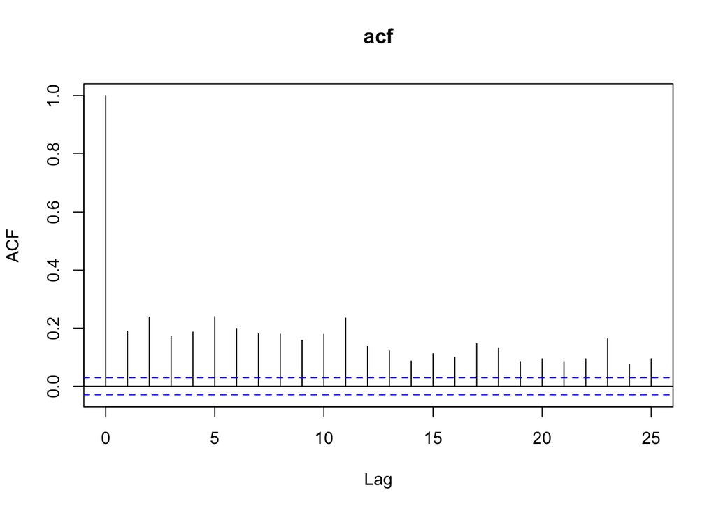

```r
squared_returns <- disney$rt^2

squared_returns <- na.omit(squared_returns)
acf_disney <- acf(squared_returns, lag.max = 25, main = "acf")
```

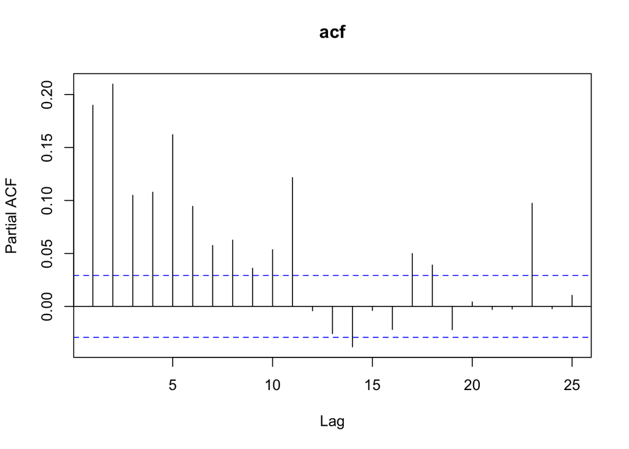

```r
pacf_disney <- pacf(squared_returns, lag.max = 25, main = "acf")
```

the volatility of returns is definetly correlated, we see that all of the squared differences of returns are above the min threshold, meaning that the magnitude of returns are serially corrrelated.

## (e) Estimate an AR(1) model for the squared returns. Is the AR(1) coefficient significant? What does that mean for rt?

```r
library(forecast)

returns_model <- arima(squared_returns, order = c(1,0,0))

returns_model
```

```
##
## Call:
## arima(x = squared_returns, order = c(1, 0, 0))
##
## Coefficients:
##          ar1  intercept
##       0.1898      3e-04
## s.e.  0.0146      0e+00
##
## sigma^2 estimated as 1.14e-06:  log likelihood = 24387.87,  aic = -48769.74
```

The AR(1) coefficient is 0.1898, with a standard error of 0.0146. If we run a t-test to see if our lag is statistically significant we get, 12.97. This is highly significant, it suggests that there is significant autocorrelation in the variance.

## (f) Estimate an ARCH(1) and a GARCH(1,1) model for

rt = μ + εt  
εt | Ωt−1 ∼ N (0, σ2t )  
## which one fits the data better (based on SIC)?

```r
library(rugarch)
library(fGarch)

# Define the returns series
# Ensure disney$rt is your return series, already computed as log differences

rt <- na.omit(disney$rt)

model_arch <- garchFit(~ garch(1,0), data = rt, trace = FALSE)
model_garch <- garchFit(~ garch(1, 1), data = rt, trace = FALSE)
summary(model_garch)
```

```
##
## Title:
##  GARCH Modelling
##
## Call:
##  garchFit(formula = ~garch(1, 1), data = rt, trace = FALSE)
##
## Mean and Variance Equation:
##  data ~ garch(1, 1)
## <environment: 0x1283fdc80>
##  [data = rt]
##
## Conditional Distribution:
##  norm
##
## Coefficient(s):
##         mu       omega      alpha1       beta1
## 3.3206e-04  6.0629e-06  7.6897e-02  9.0506e-01
##
## Std. Errors:
##  based on Hessian
##
## Error Analysis:
##         Estimate  Std. Error  t value Pr(>|t|)
## mu     3.321e-04   2.069e-04    1.605    0.108
## omega  6.063e-06   1.019e-06    5.950 2.68e-09 ***
## alpha1 7.690e-02   8.895e-03    8.645  < 2e-16 ***
## beta1  9.051e-01   1.028e-02   88.052  < 2e-16 ***
## ---
## Signif. codes:  0 '***' 0.001 '**' 0.01 '*' 0.05 '.' 0.1 ' ' 1
##
## Log Likelihood:
##  12362.38    normalized:  2.749027
##
## Description:
##  Wed May  7 21:37:57 2025 by user:
##
##
## Standardised Residuals Tests:
##                                    Statistic   p-Value
##  Jarque-Bera Test   R    Chi^2  1.215795e+04 0.0000000
##  Shapiro-Wilk Test  R    W      9.415346e-01 0.0000000
##  Ljung-Box Test     R    Q(10)  6.786412e+00 0.7454434
##  Ljung-Box Test     R    Q(15)  1.413135e+01 0.5155913
##  Ljung-Box Test     R    Q(20)  1.669564e+01 0.6726391
##  Ljung-Box Test     R^2  Q(10)  2.581260e+00 0.9896379
##  Ljung-Box Test     R^2  Q(15)  4.872409e+00 0.9931527
##  Ljung-Box Test     R^2  Q(20)  5.769536e+00 0.9991749
##  LM Arch Test       R    TR^2   3.400136e+00 0.9919991
##
## Information Criterion Statistics:
##       AIC       BIC       SIC      HQIC
## -5.496276 -5.490573 -5.496277 -5.494266
```

```r
summary(model_arch)
```

```
##
## Title:
##  GARCH Modelling
##
## Call:
##  garchFit(formula = ~garch(1, 0), data = rt, trace = FALSE)
##
## Mean and Variance Equation:
##  data ~ garch(1, 0)
## <environment: 0x128a3bd20>
##  [data = rt]
##
## Conditional Distribution:
##  norm
##
## Coefficient(s):
##         mu       omega      alpha1
## 0.00041491  0.00022968  0.30813926
##
## Std. Errors:
##  based on Hessian
##
## Error Analysis:
##         Estimate  Std. Error  t value Pr(>|t|)
## mu     4.149e-04   2.390e-04    1.736   0.0825 .
## omega  2.297e-04   6.164e-06   37.261   <2e-16 ***
## alpha1 3.081e-01   2.639e-02   11.678   <2e-16 ***
## ---
## Signif. codes:  0 '***' 0.001 '**' 0.01 '*' 0.05 '.' 0.1 ' ' 1
##
## Log Likelihood:
##  11932.03    normalized:  2.653332
##
## Description:
##  Wed May  7 21:37:57 2025 by user:
##
##
## Standardised Residuals Tests:
##                                    Statistic   p-Value
##  Jarque-Bera Test   R    Chi^2  1.730384e+04 0.0000000
##  Shapiro-Wilk Test  R    W      9.144026e-01 0.0000000
##  Ljung-Box Test     R    Q(10)  4.794783e+00 0.9044582
##  Ljung-Box Test     R    Q(15)  1.232568e+01 0.6542293
##  Ljung-Box Test     R    Q(20)  1.492669e+01 0.7805871
##  Ljung-Box Test     R^2  Q(10)  1.898566e+02 0.0000000
##  Ljung-Box Test     R^2  Q(15)  2.988620e+02 0.0000000
##  Ljung-Box Test     R^2  Q(20)  3.472614e+02 0.0000000
##  LM Arch Test       R    TR^2   1.964248e+02 0.0000000
##
## Information Criterion Statistics:
##       AIC       BIC       SIC      HQIC
## -5.305330 -5.301053 -5.305331 -5.303823
```

looks like GARCH(1,1) has a smaller AIC, and out performed in the sense of model fit

## (g) Estimate an AR(1)-ARCH(1) and a AR(1)-GARCH(1,1) model for

rt = μ + ρrt−1 + εt  
εt | Ωt−1 ∼ N (0, σ2t )

```r
arch_ar1 <- garchFit(formula = ~ arma(1,0) + garch(1,0), data = rt,
                     trace = FALSE)
garch_ar1 <- garchFit(formula = ~ + arma(1,0) + garch(1,1),
                      data = rt, trace = FALSE)

summary(garch_ar1)
```

```
##
## Title:
##  GARCH Modelling
##
## Call:
##  garchFit(formula = ~+arma(1, 0) + garch(1, 1), data = rt, trace = FALSE)
##
## Mean and Variance Equation:
##  data ~ +arma(1, 0) + garch(1, 1)
## <environment: 0x12833ae40>
##  [data = rt]
##
## Conditional Distribution:
##  norm
##
## Coefficient(s):
##          mu          ar1        omega       alpha1        beta1
##  3.4483e-04  -3.8339e-02   5.9991e-06   7.6873e-02   9.0533e-01
##
## Std. Errors:
##  based on Hessian
##
## Error Analysis:
##          Estimate  Std. Error  t value Pr(>|t|)
## mu      3.448e-04   2.073e-04    1.663   0.0962 .
## ar1    -3.834e-02   1.654e-02   -2.319   0.0204 *
## omega   5.999e-06   1.016e-06    5.905 3.53e-09 ***
## alpha1  7.687e-02   8.949e-03    8.590  < 2e-16 ***
## beta1   9.053e-01   1.032e-02   87.719  < 2e-16 ***
## ---
## Signif. codes:  0 '***' 0.001 '**' 0.01 '*' 0.05 '.' 0.1 ' ' 1
##
## Log Likelihood:
##  12365.19    normalized:  2.749654
##
## Description:
##  Wed May  7 21:37:57 2025 by user:
##
##
## Standardised Residuals Tests:
##                                    Statistic   p-Value
##  Jarque-Bera Test   R    Chi^2  1.202746e+04 0.0000000
##  Shapiro-Wilk Test  R    W      9.416881e-01 0.0000000
##  Ljung-Box Test     R    Q(10)  4.565545e+00 0.9182504
##  Ljung-Box Test     R    Q(15)  1.215103e+01 0.6675631
##  Ljung-Box Test     R    Q(20)  1.485697e+01 0.7845323
##  Ljung-Box Test     R^2  Q(10)  2.549560e+00 0.9901337
##  Ljung-Box Test     R^2  Q(15)  4.887587e+00 0.9930361
##  Ljung-Box Test     R^2  Q(20)  5.866261e+00 0.9990664
##  LM Arch Test       R    TR^2   3.365363e+00 0.9923687
##
## Information Criterion Statistics:
##       AIC       BIC       SIC      HQIC
## -5.497085 -5.489956 -5.497087 -5.494573
```

```r
summary(arch_ar1)
```

```
##
## Title:
##  GARCH Modelling
##
## Call:
##  garchFit(formula = ~arma(1, 0) + garch(1, 0), data = rt, trace = FALSE)
##
## Mean and Variance Equation:
##  data ~ arma(1, 0) + garch(1, 0)
## <environment: 0x11a888388>
##  [data = rt]
##
## Conditional Distribution:
##  norm
##
## Coefficient(s):
##          mu          ar1        omega       alpha1
##  0.00043035  -0.06320544   0.00022620   0.32829340
##
## Std. Errors:
##  based on Hessian
##
## Error Analysis:
##          Estimate  Std. Error  t value Pr(>|t|)
## mu      4.304e-04   2.407e-04    1.788  0.07380 .
## ar1    -6.321e-02   1.982e-02   -3.189  0.00143 **
## omega   2.262e-04   6.313e-06   35.833  < 2e-16 ***
## alpha1  3.283e-01   2.914e-02   11.266  < 2e-16 ***
## ---
## Signif. codes:  0 '***' 0.001 '**' 0.01 '*' 0.05 '.' 0.1 ' ' 1
##
## Log Likelihood:
##  11936.71    normalized:  2.654372
##
## Description:
##  Wed May  7 21:37:57 2025 by user:
##
##
## Standardised Residuals Tests:
##                                    Statistic   p-Value
##  Jarque-Bera Test   R    Chi^2  1.656626e+04 0.0000000
##  Shapiro-Wilk Test  R    W      9.156439e-01 0.0000000
##  Ljung-Box Test     R    Q(10)  4.868581e+00 0.8997821
##  Ljung-Box Test     R    Q(15)  1.185790e+01 0.6897517
##  Ljung-Box Test     R    Q(20)  1.396534e+01 0.8322490
##  Ljung-Box Test     R^2  Q(10)  1.833207e+02 0.0000000
##  Ljung-Box Test     R^2  Q(15)  2.890884e+02 0.0000000
##  Ljung-Box Test     R^2  Q(20)  3.363230e+02 0.0000000
##  LM Arch Test       R    TR^2   1.937637e+02 0.0000000
##
## Information Criterion Statistics:
##       AIC       BIC       SIC      HQIC
## -5.306966 -5.301263 -5.306967 -5.304956
```

GARCH(1,1) did the best but very marginally, but in reality, adding an AR(1) component didn’t really chnage much.

## (h) Plot the estimated conditional volatility of the best-fitting model among the ones considered in the previous parts.

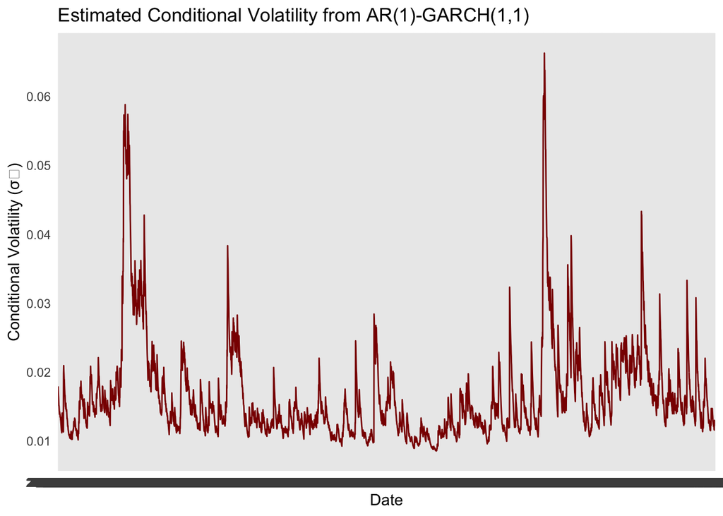

```r
cond_vol <- garch_ar1@sigma.t

# Create a dataframe with date and volatility
vol_df <- data.frame(
  date = disney$date[!is.na(disney$rt)],  # remove NA to align
  volatility = cond_vol
)

# Plot the conditional volatility
library(ggplot2)

ggplot(vol_df, aes(x = date, y = volatility, group = 1)) +
  geom_line(color = "darkred") +
  labs(
    title = "Estimated Conditional Volatility from AR(1)-GARCH(1,1)",
    x = "Date",
    y = "Conditional Volatility (σₜ)"
  ) +
  theme_minimal()
```

## (i) Use the model you chose in the previous part to forecast the conditional volatility of rt for the period of October and November of 2024. Plot your forecasts together with the estimated conditional volatility for the period between 2020 and 2024.

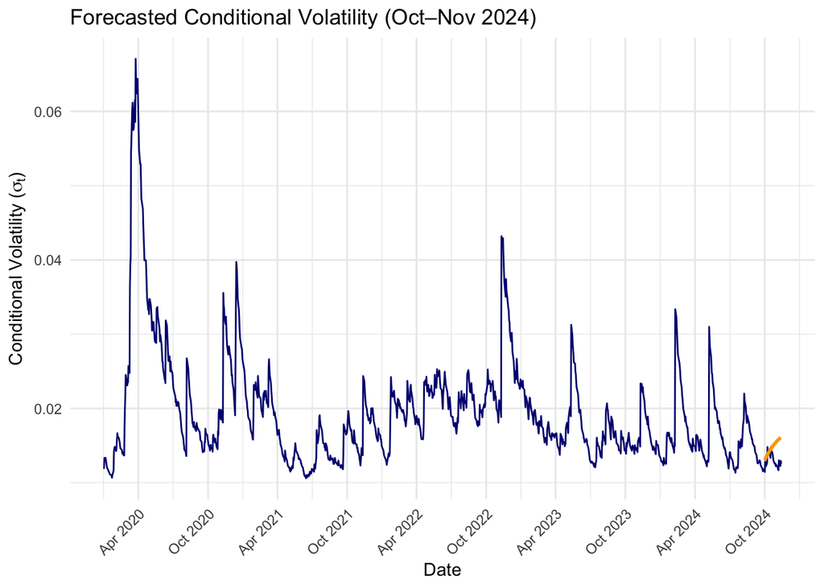

```r
# Forecast conditional volatility: 2-months ahead (approx 43 trading days)
vol_forecast <- predict(model_garch, n.ahead = 43)

# Create forecast dataframe
forecast_dates <- seq(from = as.Date("2024-10-01"), by = "day", length.out = 43)
forecast_df <- data.frame(
  date = forecast_dates,
  forecast_vol = vol_forecast$standardDeviation
)

# Combine with historical volatility from 2020 onwards
hist_vol_df <- data.frame(
  date = disney$date[-1],
  vol = model_garch@sigma.t
) %>%
  filter(date >= as.Date("2020-01-01"))

# Plot forecast + historical volatility
library(ggplot2)
hist_vol_df$date <- as.Date(hist_vol_df$date)
ggplot() +
  geom_line(data = hist_vol_df, aes(x = date, y = vol), color = "navy", linewidth = 0.5) +
  geom_line(data = forecast_df, aes(x = date, y = forecast_vol), color = "orange", linewidth = 1) +
  labs(
    title = "Forecasted Conditional Volatility (Oct–Nov 2024)",
    x = "Date",
    y = expression("Conditional Volatility (" * sigma[t] * ")")
  ) +
  theme_minimal() +
  scale_x_date(date_breaks = "6 months", date_labels = "%b %Y") +
  theme(axis.text.x = element_text(angle = 45, hjust = 1))
```